# USDA National School Lunch Program Time Series Analysis

Scout Leonard

11/16/2021

```r
library(here)
library(lubridate)
library(tidyverse)
library(zoo)
library(feasts)
library(tsibble)
library(patchwork)

options(scipen = 999)
```

# My Question:

My analysis seeks to explore the questions: Is there seasonality in how U.S. school food programs feed students? What about long-term trends, and how did any trends change in 2020 during school closures from the Covid-19 pandemic?

## Background

The National School Lunch Program (NSLP) is an enormous food system with major implications for equity in American K-12 education systems. Every day, NSLP provides ~30 million children school lunch at free or reduced prices (1). It operates in public and nonprofit private schools and residential childcare facilities (2).

To provide meals at free and reduced cost to students, participating school districts are reimbursed cash subsidies for every qualifying meal they serve. To qualify for subsidy, meals served by Nutrition Services operators must meet federal meal pattern policies which define meal content around qualifying food group combinations, sugar content, etc.

[figure not shown]

# Data Description

The Food and Nutrition Services sector of the USDA offers [monthly and annual reports](https://www.fns.usda.gov/data-research) of national participation in the National School Lunch Program and other school meal programs subsidized by the USDA (breakfast, seamless summer, supper, and snacks).

To answer my questions…

**My analysis seeks to explore the questions: Is there seasonality in how U.S. school food programs feed students? What about long-term trends, and how did any trends change in 2020 during school closures from the Covid-19 pandemic?**

… I used the National Level Monthly Data for the National School Lunch Program, which comes in PDF and Excel formats which are public. I downloaded the Excel format of the monthly data and did some tidying in Excel to make sure the .csv version would be friendly with R! There were some formatting thing like merged cells that included titles, not observations, as rows, which I eliminated before downloading as a .csv in my R project.

```r
#read in the monthly lunch data
usda_monthly <- read.csv(here("data", "usda_monthly_data_tidy.csv"))
```

Even after a little manipulation in excel, there were changes to be made for easier manipulation of my monthly lunch data dataframe. Here, I give columns more descriptive names, remove odd columns that were added to the dataframe when I read in the .csv, mutate columns to exclude “%” “-” or spaces that R cannot make sense of.

```r
#change first column name
colnames(usda_monthly)[1] <- "month"

#delete the weird columns that got added between downloading the raw data to my
#local computer and reading it to .Rmd
usda_monthly <- select(usda_monthly, -c("X", "X.1"))

#change last column name
colnames(usda_monthly)[9] <- "fiscal_year"
```

```r
#remove percent signs from percent_free_of_total_lunches and
#percent_reduced_price_of_total_lunches columns
usda_monthly <- usda_monthly %>%
 mutate(percent_free_of_total_lunches = gsub('%','', percent_free_of_total_lunches)) %>%
  mutate(percent_reduced_price_of_total_lunches = gsub('%','',percent_reduced_price_of_total_lunches)) %>%
  mutate(month = gsub("-", " ", month))
```

```r
#convert month column to class datetime from class character
usda_monthly <- usda_monthly %>%
  mutate("month" = zoo::as.yearmon(month, "%y %b"))

#check class of all columns
lapply(usda_monthly, class)

#the data in most of the columns is of class character, but needs to be numeric
usda_monthly <- usda_monthly %>%
  mutate_if(is.character, as.numeric)
```

[output not shown]

Finally, to have an initial look at my data, I make simple line graphs here:

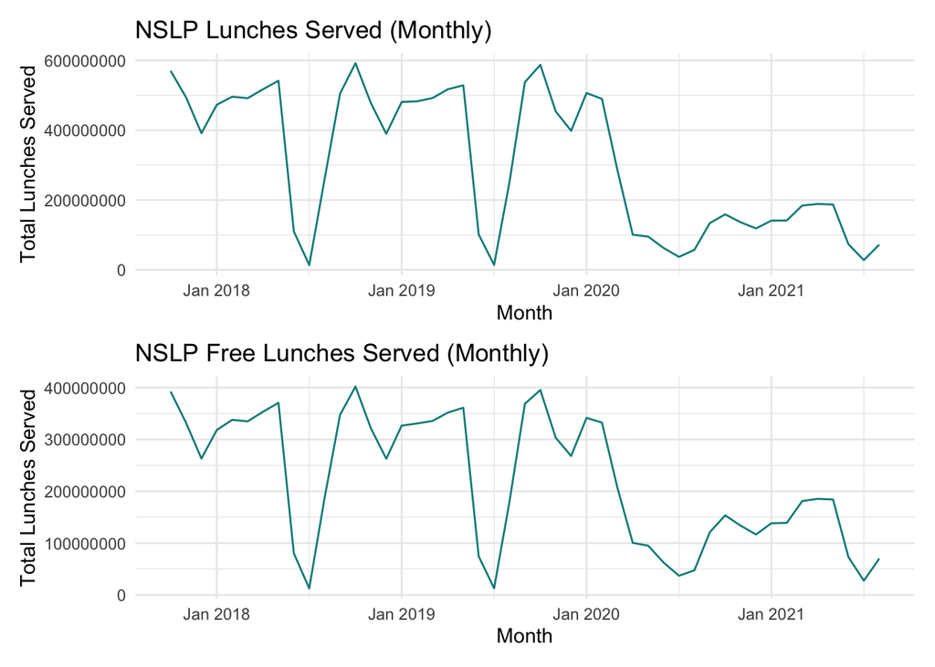

```r
#total lunches served plot
total_lunches_testplot <- ggplot(data = usda_monthly, aes(x = month, y = total_lunches_served)) +
  geom_line(color = "darkcyan") +
  theme_minimal() +
  labs(title = "NSLP Lunches Served (Monthly)",
       x = "Month",
       y = "Total Lunches Served")

usda_monthly <- usda_monthly %>%
  mutate(total_free_lunches = (total_lunches_served * percent_free_of_total_lunches) / 100)

monthly_free_testplot <- ggplot(data = usda_monthly, aes(x = month, y = total_free_lunches)) +
  geom_line(color = "darkcyan") +
  theme_minimal() +
  labs(title = "NSLP Free Lunches Served (Monthly)",
       x = "Month",
       y = "Total Lunches Served")

total_lunches_testplot / monthly_free_testplot
```

# Analysis Plan

For both, I create a tsibble with the months as class `yearmonth` and the total lunches served per month, then create an additive classical decomposition model.

I then use this model to create an autoplot which helps to visualize the presence of seasolity and long-term trends in the data for both groups.

Finally, I generate an autocorrelation function with a lag of 12 because I want to see how much participation in one month is correlated with participation for the rest of the school year.

## Total Participation in NSLP

```r
#confusingly, converting the data I want in my time series requires data of class `yearmonth` not `yearmon` I learned I can use `yearmonth()` from the tsibble package to make a tsibble with the correct time class
usda_monthly <- usda_monthly %>%
  mutate(month = yearmonth(month))

monthly_tsib <- usda_monthly %>%
  select(c(month, total_lunches_served)) %>%
  as_tsibble()
```

```r
total_decomp = monthly_tsib %>%
  model(
    classical_decomposition(total_lunches_served, type = "additive")
  ) %>%
  components()

total_auto <- autoplot(total_decomp)
```

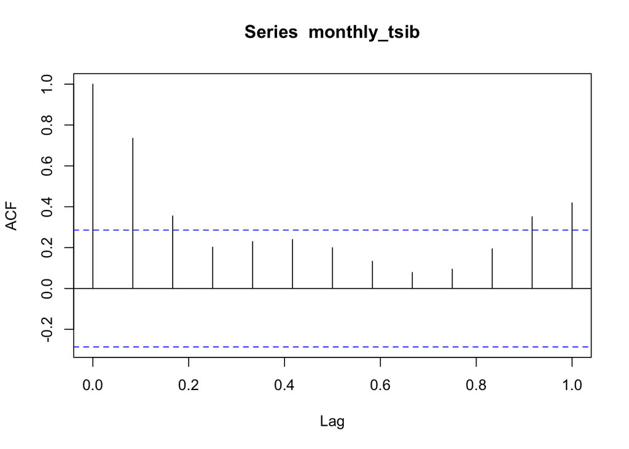

```r
total_acf <- acf(monthly_tsib, lag.max = 12)
```

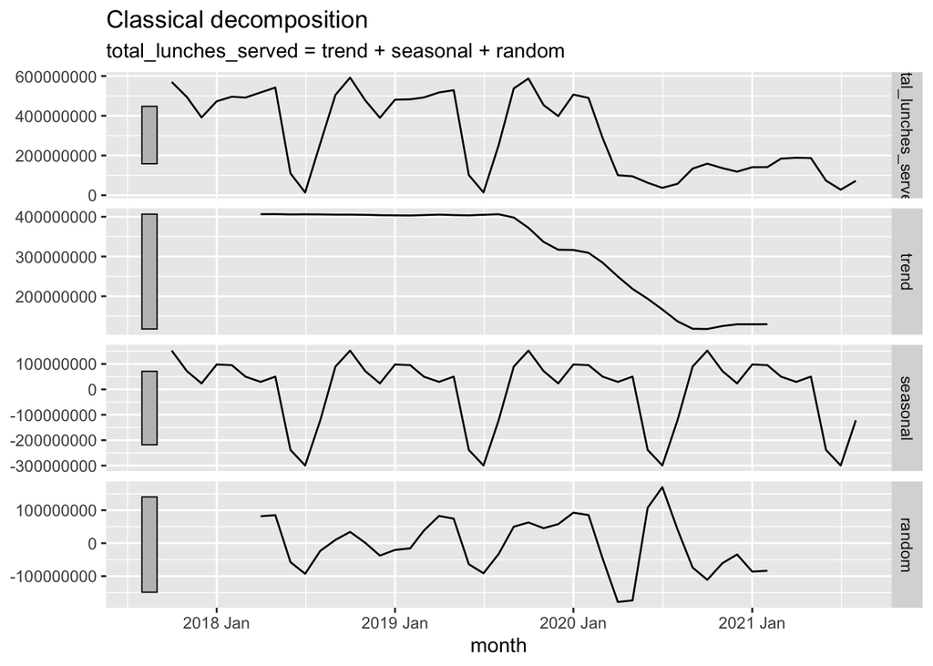

```r
total_auto
```

```r
total_acf
```

```
##
## Autocorrelations of series 'monthly_tsib', by lag
##
## 0.0000 0.0833 0.1667 0.2500 0.3333 0.4167 0.5000 0.5833 0.6667 0.7500 0.8333
##  1.000  0.735  0.355  0.202  0.230  0.240  0.200  0.133  0.079  0.094  0.194
## 0.9167 1.0000
##  0.351  0.419
```